# Exploratory Analysis of the Houston Police Department Data Set

by Natalia Fadeeva

8/16/2019

### Part 1: Data Preparation

Steps below were undertaken to collect and pre-process data for the analysis:

1. Accessed crime statistics data by street / neighborhood (police beat) for five months (January - May 2019) from the Houston Police website: http://www.houstontx.gov/police/cs/stats2.htm
2. Merged monthly data from individual Excel spreadsheet. The outcome was a data frame with 101,642 observations. Added “id” column to map records to their original file.
3. Removed columns with all “NA” values.These resulted from the merged columns in the original monthly Excel files.
4. Removed variables with large volume of missing values:
   - Zip column: January, February and March records did not contain Zip code values
   - Deemed unnecessarily large effort to replicate Zip data using April and May values
   - Suffix and Street Type columns: large number of missing values
   - Deemed not critical for the analysis
   - Dataset was reduced to 9 variables:
     - ID
     - Occurrence Date
     - Occurrence Hour
     - NIBRS Description
     - Offense Count
     - Beat
     - Premise
     - Block Range
     - Street Name
5. Removed 498 records (~0.5% of data) with incomplete (NA) values. Most of the “information” on the Houston crime problem is expressed in the resulting complete dataset with 101,144 records.
6. Changed data type of the variables to ease data manipulation
   - Converted categorical variables from character to factor class
   - Converted “Occurrence Date” to date class
7. Added Day of the Week and Month variables to the dataset to be used in the analysis.

### Part 2: Outcomes of the Exploratory Analysis of the Data

**Distribution of Offenses per Crime Occurrence**

As we can see from the boxplot below, the median number of offenses per crime occurrence was 1 across the five months of data analyzed. We can notice outliers at the higher extremes. The highest crime occurrence was recorded in March 2019, with 10 offenses.

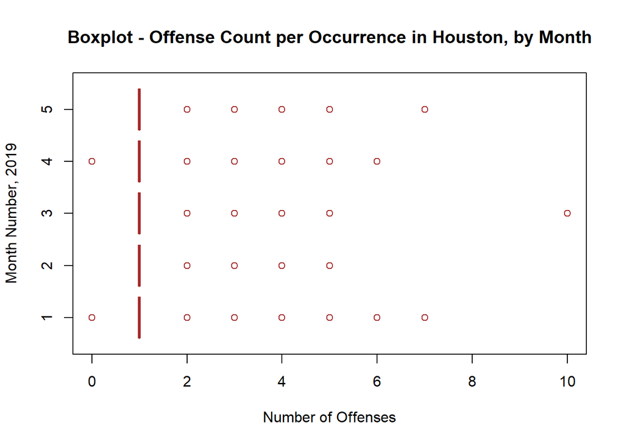

**Breakdown of Offenses by Month**

By comparing the number of crime occurrences across five months, we see that offenses were below the 20,000 mark in January, dropped in February, but then got on the upward swing in March, which continued into April with the highest number of crimes occurring in May.

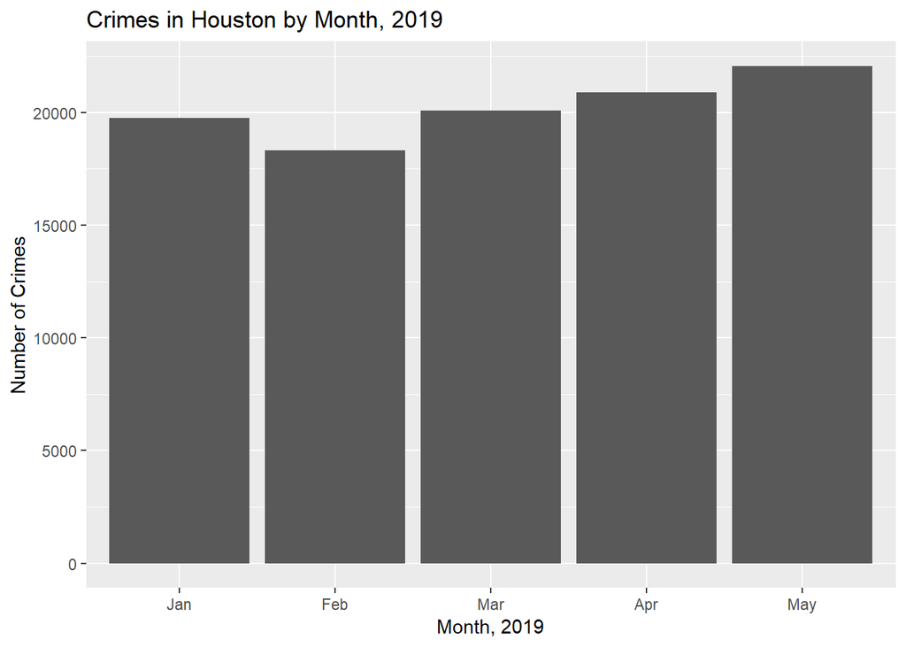

**Breakdown of Offenses by Day of Week**

By looking at the day of week groupings, we can see that more crimes occurred on Wednesday than on other days of the week during the five-month data period.

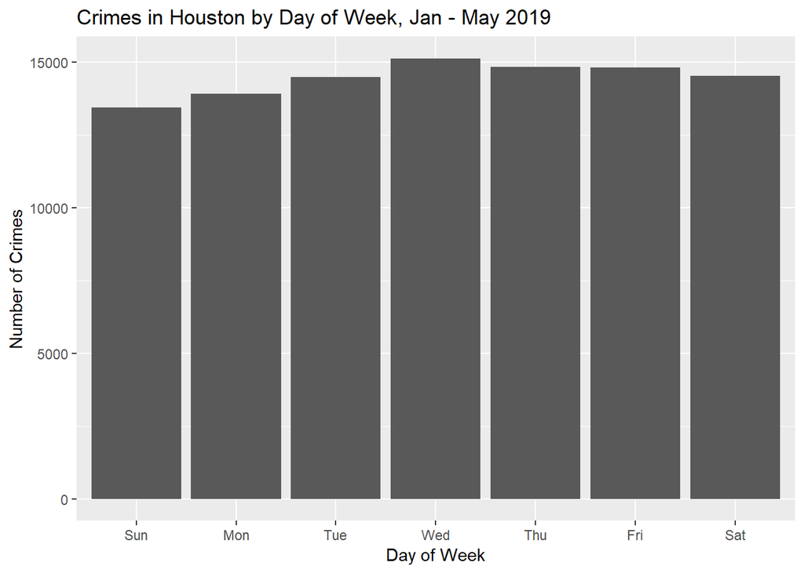

**Breakdown of Offenses by Time of Day**

By overlaying the number of crimes against the time of day data, we can that the highest number of crime occurrences (over 6,000) took place at around the 6PM time window, followed by the 12 PM time period.

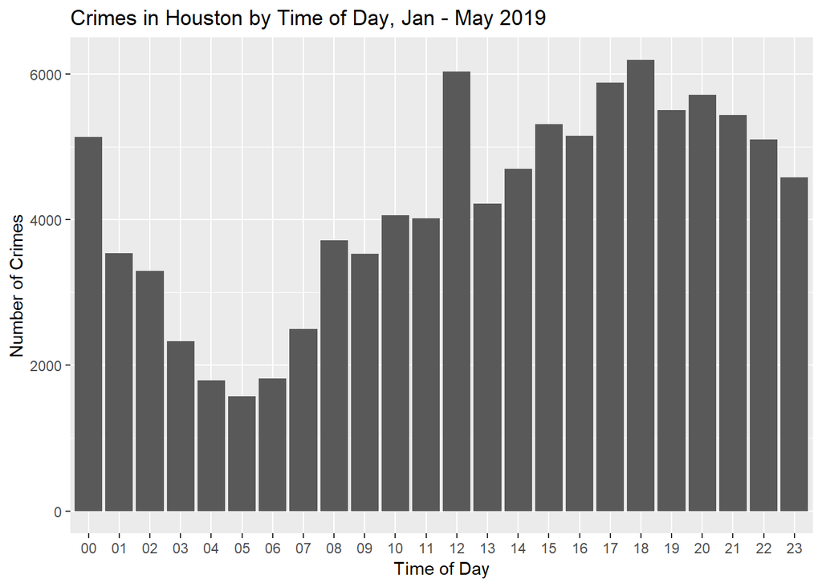

**Crime Dimension - Specific Crime Types**

After summarizing crimes by NIBRS Description, we see 59 crime types, not all of which are mutually exclusive:

```
                                        Var1  Freq
1                         Aggravated Assault  4739
2                          All other larceny  7408
3                         All other offenses  9208
4                             Animal Cruelty   130
5                                      Arson    96
6        Assisting or promoting prostitution    29
7                                 Bad checks    71
8                           Betting/wagering     4
9                                    Bribery     4
10           Burglary, Breaking and Entering  6533
11                   Counterfeiting, forgery  1013
12                    Credit card, ATM fraud  1506
13    Curfew, loitering, vagrancy violations    23
14            Destruction, damage, vandalism  8660
```

[output cut: 45 more lines]

Consolidation of similar crime categories into 12 buckets below allows for more straightforward crime analysis.

```
               Var1  Freq
1           ASSAULT 15938
2              DRUG  4566
3             FRAUD  5149
4          HOMICIDE    93
5     LARCENY/THEFT 12909
6               MVT 19705
7            NONVIO  9866
8             OTHER  9389
9  ROBBERY/BURGLARY 10065
10              SEX  1309
11         TRESPASS  2512
12              VIO  9643
```

Note: We did not have access to the Houston Police Department to confirm these crime groupings. We understand that a different set of crime classifications might be in use by the Houston PD. We feel that the goal of analyzing crime patterns could be fulfilled with the groupings above.

**Frequency of Crime**

The chart below shows frequency of crimes by category. Motor Vehicle Theft topped the list of most frequent crime occurrences in January - May 2019, followed by Assault, and Larceny/Theft. Homicides had the lowest occurrence.

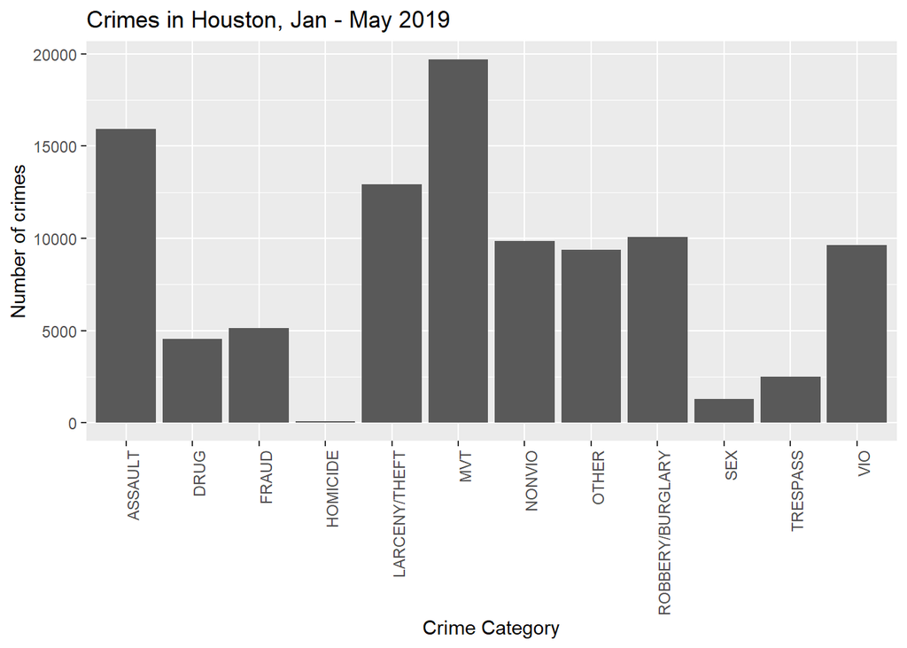

**Type of Crime**

Further roll up of crime categories into violent and non-violent crime types shows the overall nature of the crimes that were committed in Houston in the first five months in 2019. We can see that most of the crimes had a non-violent nature.

```
  Crime Type  Freq Percent
1     NONVIO 54707      54
2      Other  9389       9
3        VIO 37048      37
```

### Summary

We analyzed Houston Police data by comparing number of crime occurrences by month, day of the week, time of day, the type and frequency of crime.

The Houston Police Department does not recommend raw data comparisons be made between police beats. The web site https://www.houstontx.gov/police/cs/Monthly_Crime_Data_by_Street_and_Police_Beat.htm does not provide a comparative analysis of the various beats, thus beat-level analysis was excluded from our report.

Premise and Street / Block were not in scope for this deliverable but could be included in the next iteration of the report.